# Modelos generalizados hierárquicos

Paulo Inácio Prado  
2026-11-04

# Ponto de partida

No tutorial sobre modelos lineares generalizados (GLMs), ajustamos modelos para o número de óbitos por COVID-19 em função da idade, com dados de países com boa vigilância epidemiológica e a população de cada faixa etária como *offset*. Depois, usamos esses modelos para prever quantos óbitos o Brasil teria se a mortalidade por idade fosse a mesma desses países.

Vamos carregar novamente os dados:

```r
library(dplyr)
library(ggplot2)
library(knitr)
repo <- "https://raw.githubusercontent.com/BIE5781/2026/main/Tutoriais/"
obitos <- readRDS(gzcon(url(paste0(repo, "obitos_covid_paises_selecionados.rds"))))
pop.br <- readRDS(gzcon(url(paste0(repo, "pop_brasileira_censo_2022.rds"))))
obitos.br <- 614186
```

Nos dois modelos daquele tutorial, todas as observações eram tratadas como réplicas de um mesmo processo: a taxa de mortalidade em cada faixa etária seria a mesma em todos os países. É assim que vemos os dados quando ignoramos de qual país vem cada observação:

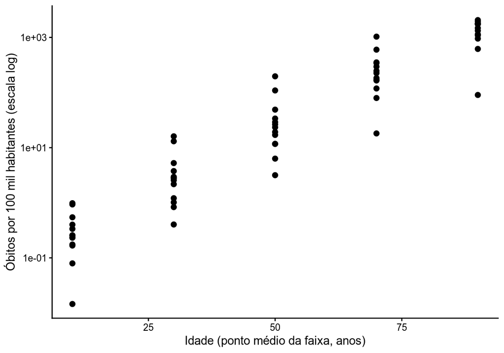

```r
ggplot(obitos, aes(idade.meio, taxa)) +
    geom_point(size = 2) +
    scale_y_log10() +
    labs(x = "Idade (ponto médio da faixa, anos)",
         y = "Óbitos por 100 mil habitantes (escala log)") +
    theme_classic()
```

Há uma relação evidente entre o logaritmo da taxa e a idade, com bastante variação em torno dela. Agora vamos identificar os países, com uma cor para cada um, e ligar os pontos de um mesmo país:

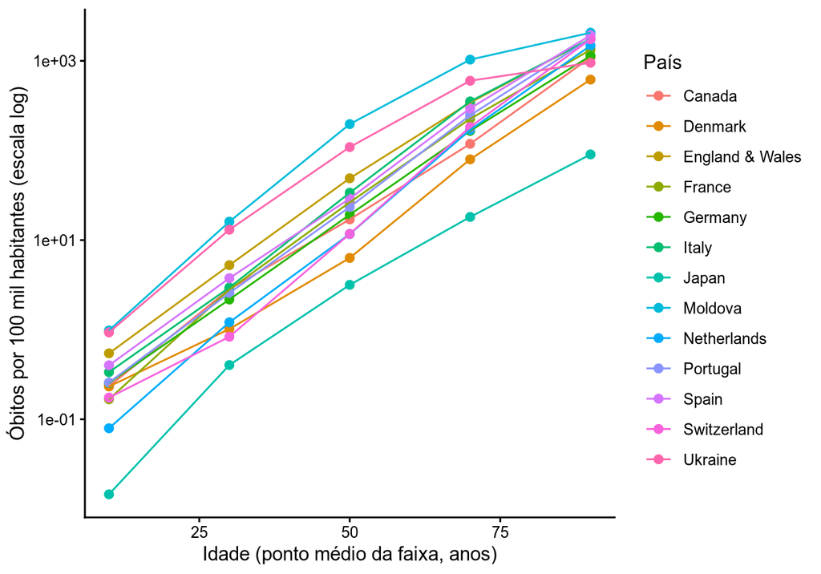

```r
ggplot(obitos, aes(idade.meio, taxa, color = pais)) +
    geom_point(size = 2) +
    geom_line() +
    scale_y_log10() +
    labs(x = "Idade (ponto médio da faixa, anos)",
         y = "Óbitos por 100 mil habitantes (escala log)", color = "País") +
    theme_classic()
```

O gráfico mostra que os países com mortalidade alta numa faixa etária tendem a ter mortalidade alta em todas as faixas, e o mesmo vale para os países com mortalidade baixa. Parte da variação nos dados se deve, portanto, a **diferenças entre países, que são consistentes entre as faixas etárias**. Isso implica que as linhas no gráfico são aproximadamente paralelas: os países diferem mais no intercepto da relação linear, do que na sua inclinação.

## Por que os modelos anteriores não dão conta dessa variação

- No **modelo Poisson**, a única variação em torno da curva média é a da própria Poisson, cuja variância é igual à média. Com milhares de óbitos por faixa etária, essa variação é muito pequena em relação às diferenças entre os países. Os dados têm muito mais variação do que o modelo prevê, e é isso que chamamos de **sobredispersão**.
- O **modelo binomial negativo** (gama-Poisson) acomoda a sobredispersão supondo que cada observação tem sua própria taxa, sorteada de uma distribuição gama em torno da curva média. Com isso, a variação prevista ficou parecida com a dos dados. Mas os desvios são sorteados de forma **independente** para cada observação, como se o desvio de um país numa faixa etária não dissesse nada sobre o desvio do mesmo país em outra faixa. O gráfico acima mostra que não é assim.

A sobredispersão, portanto, nem sempre é só “variação demais”. Muitas vezes, ela é o sinal de que há um fator que afeta as observações e que não está no modelo. Aqui, esse fator é o país: tudo o que faz um país ter mortalidade mais alta ou mais baixa que os outros em todas as idades, como a dinâmica das ondas da epidemia, a vacinação, o sistema de saúde e a forma de registrar os óbitos. Assim, podemos imaginar que este fator segue uma distribuição, que expressa a sua variação entre países.

# O modelo hierárquico

## Especificação

Vamos permitir que cada país tenha o seu próprio intercepto, mantendo a mesma inclinação para todos:

$$\begin{aligned}
Y_{ij} &\sim \text{Poisson}(\lambda_{ij}) \\
\ln \lambda_{ij} &= \ln P_{ij} + \beta_{0j} + \beta_1 \, d_i \\
\beta_{0j} &\sim \text{Normal}(\bar{\beta}_0, \, \sigma_P) \\
\bar{\beta}_0 &\sim \text{Normal}(\ln 100, \, 2) \\
\beta_1 &\sim \text{Normal}(1, \, 0{,}5) \\
\sigma_P &\sim \text{Exponencial}(1)
\end{aligned}$$

em que $Y_{ij}$ é o número de óbitos na faixa etária $i$ do país $j$, $P_{ij}$ é a população dessa faixa (em 100 mil habitantes) e $d_i = (x_i - 50)/10$ é a idade em **décadas** a partir dos 50 anos, sendo $x_i$ o ponto médio da faixa etária, em anos, como no tutorial sobre GLMs. As distribuições a priori de $\bar{\beta}_0$ e $\beta_1$ são as mesmas que usamos para $\beta_0$ e $\beta_1$ naquele tutorial.

A novidade está na terceira linha. O intercepto $\beta_{0j}$, que é o logaritmo da taxa de mortalidade aos 50 anos no país $j$, não é mais o mesmo para todos os países. Os interceptos dos países vêm de uma distribuição normal, com média $\bar{\beta}_0$ e desvio-padrão $\sigma_P$. Os parâmetros desta distribuição normal de interceptos também são estimados a partir dos dados, e por isso têm as suas próprias distribuições a priori. É por ter esse segundo nível de parâmetros que o modelo é chamado de **hierárquico**.

- $\bar{\beta}_0$ tem o papel do intercepto dos modelos anteriores: é o logaritmo da taxa aos 50 anos num país típico. Por isso, mantivemos a mesma distribuição a priori.
- $\sigma_P$ mede o quanto os países diferem entre si. Como está na escala logarítmica, um país que esteja $\sigma_P$ acima da média tem uma taxa $e^{\sigma_P}$ vezes maior, em todas as idades. A distribuição a priori $\text{Exponencial}(1)$ tem média 1, ou seja, considera plausíveis diferenças de cerca de $e^1 \approx 2{,}7$ vezes entre um país típico e um país um desvio-padrão acima da média, mas admite diferenças maiores.

A partir desses dados, o modelo estima ao mesmo tempo o intercepto de cada país e a distribuição dos interceptos dos países. As estimativas de cada país são “puxadas” na direção da média, tanto mais quanto menos informação houver sobre o país. Isso é o **agrupamento parcial** (*partial pooling*), que já vimos no tutorial anterior sobre modelos hierárquicos: um meio-termo entre ignorar os países (os modelos anteriores) e estimar uma regressão para cada país separadamente, como se nada soubéssemos sobre um país a partir dos outros.

## Ajuste

Precisamos de uma variável com o índice de cada país, de 1 até o número de países. Uma forma simples é converter o nome do país em fator, e o fator em número inteiro:

```r
library(rethinking)

dados <- list(
    obitos  = obitos$obitos,
    log_pop = log(obitos$pop.e5),
    idade_d = (obitos$idade.meio - 50) / 10,   # décadas a partir dos 50 anos
    pais    = as.integer(factor(obitos$pais))
)
## Confira a correspondência entre os nomes e os índices
paises <- levels(factor(obitos$pais))
paises
```

Na especificação do modelo, `b0[pais]` indica que há um intercepto para cada valor do índice `pais`. A distribuição desses interceptos tem dois parâmetros, `b0_media` e `sigma_pais`, cada um com a sua distribuição a priori. Indicamos também os valores iniciais das cadeias com o argumento `start` (veja a nota logo abaixo do ajuste):

```r
m3 <- ulam(
    alist(
        obitos ~ dpois(lambda),
        log(lambda) <- log_pop + b0[pais] + b1 * idade_d,
        b0[pais] ~ dnorm(b0_media, sigma_pais),
        b0_media ~ dnorm(4.6, 2),       # 4,6 é aproximadamente ln(100)
        b1 ~ dnorm(1, 0.5),             # aumento do log da taxa por década
        sigma_pais ~ dexp(1)
    ),
    data = dados, chains = 4, cores = 4,
    start = list(b0 = rep(4.6, length(paises)), b0_media = 4.6,
                 b1 = 1, sigma_pais = 1))
```

### Nota: por que medir a idade em décadas?

No tutorial sobre GLMs, mencionamos que a idade em décadas facilita o trabalho do algoritmo de amostragem. Neste modelo, isso faz uma grande diferença. Com a idade em anos, ele gera o aviso `transitions hit the maximum treedepth limit of 10`. Ele indica que o amostrador precisou de passos demais em cada iteração. O motivo é a diferença de escala entre os parâmetros. Com milhares de óbitos por faixa etária, a inclinação é estimada com enorme precisão: com a idade em anos, o desvio-padrão da posterior de $\beta_1$ é de cerca de 0,0001, enquanto o de $\bar{\beta}_0$ é de cerca de 0,3. O algoritmo do Stan usa passos de tamanho parecido para todos os parâmetros. Para se mover com segurança na direção de $\beta_1$, os passos precisam ser minúsculos, e são necessários muitos deles para percorrer a posterior de $\bar{\beta}_0$.

Com a idade em décadas, $\beta_1$ e o seu desvio-padrão ficam 10 vezes maiores, e as escalas dos parâmetros ficam mais parecidas. O aviso desaparece, o tamanho efetivo das amostras (`ess_bulk`) dos parâmetros da população de países aumenta mais de dez vezes, e o ajuste fica mais rápido. As estimativas não mudam: com a idade em anos, $\beta_1$ seria o mesmo valor dividido por 10. Mudar a unidade de uma variável preditora para deixar os parâmetros em escalas parecidas é um recurso simples e muito útil para melhorar a amostragem.

### Nota: valores iniciais das cadeias

Se não indicarmos os valores iniciais, a função `ulam()` sorteia valores entre -2 e 2 para cada parâmetro (na escala em que o Stan trabalha, que para $\sigma_P$ é a logarítmica). Para muitos modelos isso funciona, mas aqui as contagens são muito grandes. Uma combinação ruim de valores iniciais pode prever números de óbitos ordens de grandeza diferentes dos observados, e as cadeias podem demorar a sair dessa região ou não convergir. Com a idade em anos, isso de fato aconteceu: uma inclinação inicial de 2 por ano implica que a taxa se multiplica por $e^{80}$ entre os 50 e os 90 anos.

Usamos como valores iniciais os centros das distribuições a priori:

- `b0 = 4.6` para todos os países e `b0_media = 4.6`: todos os países começam iguais ao país típico, com 100 óbitos por 100 mil habitantes aos 50 anos. Nos dados, essa taxa varia entre cerca de 3 e 200 entre os países, então o valor inicial está na ordem de grandeza certa.
- `b1 = 1`: a taxa se multiplica por $e^1 \approx 2{,}7$ a cada década, próximo do aumento de cerca de 2,4 vezes por década da lei de Gompertz.
- `sigma_pais = 1`: a média da distribuição a priori.

São valores plausíveis antes de ver os dados, e por isso não favorecem nenhum resultado em particular: as cadeias apenas começam numa região razoável. Com a idade em décadas, as cadeias convergem mesmo sem o argumento `start`, mas indicar valores iniciais plausíveis é uma boa prática quando as contagens são grandes. Um cuidado: o valor indicado em `start` é o mesmo para as quatro cadeias. Cadeias que partem do mesmo ponto podem concordar entre si sem ter explorado toda a posterior, o que torna o diagnóstico `rhat` menos informativo.

### Nota: e a parametrização não-centrada?

No tutorial anterior sobre modelos hierárquicos, vimos que a **parametrização não-centrada** costuma melhorar a amostragem. Nela, cada intercepto é escrito como a média mais um desvio padronizado, multiplicado pelo desvio-padrão entre grupos, $\beta_{0j} = \bar{\beta}_0 + z_j \, \sigma_P$, com $z_j \sim \text{Normal}(0, 1)$:

```r
m3nc <- ulam(
    alist(
        obitos ~ dpois(lambda),
        log(lambda) <- log_pop + b0 + bz[pais] * sigma_pais + b1 * idade_d,
        b0 ~ dnorm(4.6, 2),
        bz[pais] ~ dnorm(0, 1),
        b1 ~ dnorm(1, 0.5),
        sigma_pais ~ dexp(1),
        gq> vector[pais]:b <<- b0 + bz * sigma_pais   # intercepto de cada país
    ),
    data = dados, chains = 4, cores = 4,
    start = list(b0 = 4.6, bz = rep(0, length(paises)), b1 = 1, sigma_pais = 1))
```

Aqui, porém, o modelo não-centrado é uma escolha pior, pois volta o aviso de `treedepth`. Além disso o tamanho amostral efetivo (`ess_bulk`) dos `b0`, dos `bz` e de `sigma_pais` fica abaixo de 150, contra mais de 1.400 no modelo centrado. Por fim, a métrica de convergência Rhat ultrapassa o valor limite de 1.01 para muitas estimativas. Compare:

```r
precis(m3, depth = 2)
precis(m3nc, depth = 2)
```

A parametrização não-centrada resolve um problema específico: quando há **pouca informação sobre cada grupo**, a posterior dos interceptos depende muito de $\sigma_P$. Quando $\sigma_P$ é pequeno, os interceptos ficam todos espremidos perto da média, e quando é grande, espalham-se. A posterior tem a forma de um funil, difícil de percorrer. Nesse caso, separar o desvio padronizado $z_j$ de $\sigma_P$ desfaz o funil.

Nos nossos dados ocorre o oposto: cada país tem milhares de óbitos, e os dados determinam o intercepto de cada país com grande precisão (desvio-padrão da posterior em torno de 0,005), seja qual for o valor de $\sigma_P$. Não há funil na parametrização centrada. Na não-centrada, ao contrário, o intercepto de cada país passa a ser a combinação $\bar{\beta}_0 + z_j \, \sigma_P$. Como essa combinação é fixada pelos dados, $\bar{\beta}_0$, $z_j$ e $\sigma_P$ ficam fortemente correlacionados na posterior, que vira uma crista estreita, também difícil de percorrer. A regra prática é: **dados fortes em cada grupo, parametrização centrada; dados fracos, não-centrada**.

# Resultados do modelo ajustado

Confira a convergência (`rhat` e `ess_bulk`) e as estimativas. Com `depth = 2`, a função `precis()` mostra também o intercepto de cada país:

```r
precis(m3, depth = 2, prob = 0.95)
```

[output not shown]

A exponencial de $\bar{\beta}_0$ (`b0_media`) é a taxa esperada de óbitos aos 50 anos de idade num país típico:

```r
## extrai a posterior dos parâmetros do modelo
post <- extract.samples(m3)
## Taxa de óbitos por 100 mil habitantes aos 50 anos num país típico
quantile(exp(post$b0_media), c(0.025, 0.5, 0.975))
```

A posterior de $\beta_1$ (`b1`) descreve o aumento esperado (em escala multiplicativa) na mortalidade a cada década de idade:

```r
## Quantas vezes a taxa aumenta a cada década de idade
quantile(exp(post$b1), c(0.025, 0.5, 0.975))
```

Compare com as estimativas deste coeficiente obtidas com os modelos equivalentes não hierárquicos, do tutorial sobre glms. Houve uma grande mudança?

Finalmente, a exponencial de $\sigma_P$ (`sigma_pais`) é o quanto a taxa de um país um desvio-padrão acima da média é maior que a de um país típico:

```r
## Quantas vezes a taxa de um país um desvio-padrão acima da média
## é maior que a de um país típico
quantile(exp(post$sigma_pais), c(0.025, 0.5, 0.975))
```

## Previsões para os países usados no ajuste

### Posterior da taxa média de cada país

Como no tutorial sobre GLMs, vamos calcular a posterior da taxa por 100 mil habitantes, agora para cada país. Para isso, a tabela de valores para as previsões precisa ter também o índice do país. Criamos uma grade com todas as combinações de idades e países, com $\ln P = 0$:

```r
idade.grade <- seq(10, 90, length.out = 50)
grade <- expand.grid(idade.meio = idade.grade, pais = seq_along(paises))
grade.lista <- list(idade_d = (grade$idade.meio - 50) / 10,
                    pais = grade$pais,
                    log_pop = rep(0, nrow(grade)))   # população de 100 mil

taxa.post3 <- link(m3, data = grade.lista)   # amostras x (idades x países)
IC3 <- apply(taxa.post3, 2, PI, prob = 0.95)
previstos3 <- data.frame(idade.meio = grade$idade.meio,
                         pais = paises[grade$pais],
                         media = colMeans(taxa.post3),
                         inf = IC3[1, ], sup = IC3[2, ])
```

```r
ggplot(obitos, aes(idade.meio, taxa, color = pais)) +
    geom_line(data = previstos3, aes(y = media)) +
    geom_point(size = 2) +
    scale_y_log10() +
    labs(x = "Idade (ponto médio da faixa, anos)",
         y = "Óbitos por 100 mil habitantes (escala log)", color = "País") +
    theme_classic()
```

[output not shown]

O código acima também calculou o intervalo de 95% da posterior da taxa de cada país (colunas `inf` e `sup` de `previstos3`). Confira os valores no objeto `previstos3`. Note que os intervalos são tão estreitos que não apareceriam no gráfico. Por quê?

### Distribuição preditiva dos totais de óbitos de cada país

E a distribuição preditiva? No tutorial sobre GLMs, simulamos os óbitos em populações de 100 mil habitantes. Mas a variação da Poisson depende do tamanho da população. Para comparar a previsão com os dados, o correto é simular os óbitos com a **população real** de cada faixa etária de cada país. Basta usar a função `sim()` sem o argumento `data`, o que faz a simulação para os mesmos dados usados no ajuste:

```r
obitos.sim3 <- sim(m3)        # óbitos simulados: amostras x observações
dim(obitos.sim3)
```

Cada coluna de `obitos.sim3` é uma linha da tabela `obitos`, ou seja, uma faixa etária de um país. Somando as colunas de cada país, obtemos a distribuição preditiva posterior do **total de óbitos** do país, que podemos comparar com o total observado:

```r
totais <- do.call(rbind, lapply(paises, function(p) {
    colunas <- obitos$pais == p
    total.sim <- rowSums(obitos.sim3[, colunas])
    data.frame(pais = p,
               observado = sum(obitos$obitos[colunas]),
               media = mean(total.sim),
               inf = PI(total.sim, prob = 0.95)[1],
               sup = PI(total.sim, prob = 0.95)[2])
}))
kable(totais, digits = 0, row.names = FALSE,
      col.names = c("País", "Observado", "Média prevista", "2,5%", "97,5%"),
      format.args = list(big.mark = ".", decimal.mark = ","))
```

| País | Observado | Média prevista | 2,5% | 97,5% |
| --- | --- | --- | --- | --- |
| Canada | 29.390 | 29.384 | 28.910 | 29.884 |
| Denmark | 2.850 | 2.850 | 2.698 | 2.989 |
| England & Wales | 98.475 | 98.462 | 97.604 | 99.357 |
| France | 91.520 | 91.517 | 90.654 | 92.439 |
| Germany | 99.611 | 99.609 | 98.738 | 100.477 |
| Italy | 132.880 | 132.892 | 131.839 | 133.873 |
| Japan | 17.563 | 17.559 | 17.235 | 17.913 |
| Moldova | 8.135 | 8.130 | 7.895 | 8.378 |
| Netherlands | 19.048 | 19.048 | 18.671 | 19.439 |
| Portugal | 18.417 | 18.421 | 18.061 | 18.777 |
| Spain | 87.758 | 87.743 | 86.877 | 88.573 |
| Switzerland | 11.080 | 11.077 | 10.798 | 11.360 |
| Ukraine | 80.908 | 80.891 | 80.129 | 81.698 |

O modelo parece se sair muito bem para estimar totais de casos por país. Mas como será seu desempenho para estimar as taxas a cada faixa etária? Para avaliar isso, vamos comparar os óbitos observados com a distribuição preditiva de cada faixa, para os dois países mais extremos: o de maior e o de menor intercepto ($\beta_{0j}$), ou seja, com as maiores e as menores taxas de mortalidade previstas em todas as idades:

```r
## Média da posterior do intercepto de cada país
post <- extract.samples(m3)
b0.pais <- colMeans(post$b0)
## Países de maior e de menor intercepto
selecionados <- paises[c(which.max(b0.pais), which.min(b0.pais))]
selecionados
```

```
[1] "Moldova" "Japan"
```

```r
## Observados, média e intervalo de 95% da preditiva por faixa etária
faixas <- do.call(rbind, lapply(selecionados, function(p) {
    linhas <- which(obitos$pais == p)
    IC <- apply(obitos.sim3[, linhas], 2, PI, prob = 0.95)
    data.frame(pais = p,
               idade = obitos$idade[linhas],
               observado = obitos$obitos[linhas],
               media = colMeans(obitos.sim3[, linhas]),
               inf = IC[1, ], sup = IC[2, ])
}))
kable(faixas, digits = 0, row.names = FALSE,
      col.names = c("País", "Faixa etária", "Observado", "Média prevista",
                    "2,5%", "97,5%"),
      format.args = list(big.mark = ".", decimal.mark = ","))
```

| País | Faixa etária | Observado | Média prevista | 2,5% | 97,5% |
| --- | --- | --- | --- | --- | --- |
| Moldova | 0-19 | 6 | 22 | 13 | 31 |
| Moldova | 20-39 | 115 | 155 | 130 | 182 |
| Moldova | 40-59 | 1.350 | 895 | 836 | 958 |
| Moldova | 60-79 | 5.402 | 4.132 | 3.986 | 4.287 |
| Moldova | 80+ | 1.262 | 2.926 | 2.804 | 3.047 |
| Japan | 0-19 | 3 | 15 | 8 | 23 |
| Japan | 20-39 | 107 | 117 | 95 | 139 |
| Japan | 40-59 | 1.101 | 923 | 864 | 982 |
| Japan | 60-79 | 5.786 | 5.133 | 4.976 | 5.296 |
| Japan | 80+ | 10.566 | 11.372 | 11.117 | 11.622 |

# Quantos óbitos o Brasil teria?

## O Brasil como um novo país

Vamos preparar a população brasileira como no tutorial sobre GLMs, com uma única classe para 80 anos ou mais:

```r
pop.br80 <- pop.br |>
    mutate(acima80 = idade.meio > 80,
           classe = ifelse(acima80, "80 anos ou mais", as.character(idade)),
           idade.meio = ifelse(acima80, 90, idade.meio)) |>
    group_by(classe, idade.meio) |>
    summarise(pop = sum(pop), .groups = "drop") |>
    arrange(idade.meio)
```

Mas há um cuidado. A compensação dos erros depende da pirâmide etária. A população brasileira é mais jovem que a dos países usados no ajuste, e por isso os erros nas faixas mais jovens e intermediárias pesam mais no total do Brasil do que no total desses países. Um modelo com inclinações por país levaria em conta também a incerteza sobre a forma da curva (veja no final deste tutorial).

O Brasil não está entre os países usados no ajuste, e por isso não tem um intercepto estimado. Mas o modelo descreve a distribuição de interceptos, como uma $\text{Normal}(\bar{\beta}_0, \sigma_P)$. Supondo que o Brasil também faz parte desta distribuição, o seu intercepto é um sorteio dessa distribuição.

Então, para obter a posterior do número de óbitos no Brasil, fazemos o seguinte, para cada amostra $s$ da posterior:

1. Sorteamos um intercepto para o Brasil, $\beta_{0,\text{BR}} \sim \text{Normal}(\bar{\beta}_{0,s}, \, \sigma_{P,s})$.
2. Calculamos o número esperado de óbitos em cada faixa etária $i$: $\lambda_{i} = P_{i} \, e^{\beta_{0,\text{BR}} + \beta_{1,s} \, d_i}$.
3. Sorteamos o número de óbitos em cada faixa de uma $\text{Poisson}(\lambda_i)$ e somamos as faixas.

Note que o intercepto do Brasil é sorteado **uma vez** por amostra da posterior e vale para **todas** as faixas etárias. É assim que o modelo representa um país com mortalidade mais alta ou mais baixa em todas as idades.

```r
post <- extract.samples(m3)
S <- length(post$b1)

## 1. Um intercepto sorteado para o Brasil em cada amostra da posterior
set.seed(42)
b0.br <- rnorm(S, mean = post$b0_media, sd = post$sigma_pais)

## 2. Óbitos esperados em cada faixa etária: amostras (linhas) x faixas (colunas)
lambda.br3 <- sapply(seq_len(nrow(pop.br80)), function(i)
    pop.br80$pop[i] / 1e5 * exp(b0.br + post$b1 * (pop.br80$idade.meio[i] - 50) / 10))
total.esperado3 <- rowSums(lambda.br3)

## 3. Óbitos sorteados de uma Poisson em cada faixa, e o total
obitos.sim.br3 <- matrix(rpois(length(lambda.br3), lambda.br3), nrow = S)
total.sim3 <- rowSums(obitos.sim.br3)
## Media e intervalo do total de obitos previsto
mean(total.sim3)
PI(total.sim3, prob = 0.95)
## Probabilidade de um total de obitos maior que o observado no Brasil
mean(total.sim3 > obitos.br)
```

[output not shown]

Para ver o impacto da incerteza introduzida pela distribuição de interceptos, compare com a posterior obtida sempre com o mesmo valor de intercepto, como fizemos nas seções anteriores, como fizemos para calcular o número de óbitos previsto por país. Aqui vamos calcular a posterior do total de obitos para o Brasil, mas fixando o intercepto em sua média ($\bar{\beta}_0$). Com isso, obtemos a posterior de óbitos para o Brasil, caso fosse como um **país típico** quanto à mortalidade.

```r
lambda.tipico <- sapply(seq_len(nrow(pop.br80)), function(i)
    pop.br80$pop[i] / 1e5 * exp(post$b0_media + post$b1 * (pop.br80$idade.meio[i] - 50) / 10))
total.tipico <- rowSums(matrix(rpois(length(lambda.tipico), lambda.tipico), nrow = S))
## Intervalo
PI(total.tipico, prob = 0.95)
## Probabilidade de n obitos maior que o do Brasil
mean(total.tipico > obitos.br)
```

[output not shown]

Os dois intervalos são muito diferentes. O primeiro responde à pergunta “quantos óbitos teria **um país qualquer** dessa população de países, com a pirâmide etária do Brasil?”. O segundo, “quantos óbitos teria **o país típico**”, se tivesse a pirâmide etária do Brasil? Qual das duas perguntas nos interessa?

```r
dens(total.tipico, xlim = range(c(total.sim3, obitos.br)),
     xlab = "Total de óbitos no Brasil",
     ylab = "Densidade posterior", col=1)
dens(total.sim3, add=TRUE, col=2)
abline(v = obitos.br, col = 3, lwd = 2)
legend("topright", legend = c("Típico", "Qualquer", "Observado"), col = 1:3, lwd = 2, bty = "n")
```

[output not shown]

## Comparação com os modelos anteriores

Para comparar os três modelos, precisamos também das previsões dos modelos `m1` (Poisson) e `m2` (gama-Poisson) do tutorial sobre GLMs. Se eles não estiverem na sua sessão, ajuste-os novamente, com o mesmo código daquele tutorial:

```r
m1 <- ulam(
    alist(
        obitos ~ dpois(lambda),
        log(lambda) <- log_pop + b0 + b1 * idade_d,
        b0 ~ dnorm(4.6, 2),        # 4,6 é aproximadamente ln(100)
        b1 ~ dnorm(1, 0.5)         # aumento do log da taxa por década
    ),
    data = dados, chains = 4, cores = 4,
    start = list(b0 = 4.6, b1 = 1))

m2 <- ulam(
    alist(
        obitos ~ dgampois(lambda, phi),
        log(lambda) <- log_pop + b0 + b1 * idade_d,
        b0 ~ dnorm(4.6, 2),
        b1 ~ dnorm(1, 0.5),
        phi ~ dexp(1)
    ),
    data = dados, chains = 4, cores = 4,
    start = list(b0 = 4.6, b1 = 1, phi = 1))
```

E calcule a distribuição preditiva do total de óbitos no Brasil para cada um deles, como no tutorial sobre GLMs:

```r
dados.br <- list(idade_d = (pop.br80$idade.meio - 50) / 10,
                 log_pop = log(pop.br80$pop / 1e5))
total.sim1 <- rowSums(sim(m1, data = dados.br))
total.sim2 <- rowSums(sim(m2, data = dados.br))
```

Agora, uma tabela com a média, o intervalo de 95% e a probabilidade de um total maior ou igual ao observado, segundo cada modelo:

```r
resume <- function(total) {
    c(media = mean(total), PI(total, prob = 0.95),
      p.obs = mean(total >= obitos.br))
}
comparacao <- rbind(
    "Poisson" = resume(total.sim1),
    "Gama-Poisson" = resume(total.sim2),
    "Poisson hierárquico: país típico" = resume(total.tipico),
    "Poisson hierárquico: novo país" = resume(total.sim3))
kable(comparacao, digits = c(0, 0, 0, 3),
      col.names = c("Média", "2,5%", "97,5%", "P(total ≥ observado)"),
      format.args = list(big.mark = ".", decimal.mark = ","))
```

|  | Média | 2,5% | 97,5% | P(total ≥ observado) |
| --- | --- | --- | --- | --- |
| Poisson | 122.461 | 121.718 | 123.197 | 0,000 |
| Gama-Poisson | 184.054 | 64.215 | 430.379 | 0,003 |
| Poisson hierárquico: país típico | 137.108 | 77.796 | 226.451 | 0,000 |
| Poisson hierárquico: novo país | 229.595 | 18.390 | 928.491 | 0,055 |

## Como um modelo Poisson acomoda a sobredispersão

O modelo hierárquico usa a distribuição de Poisson, que não tem variação além da que é determinada pela média. Como, então, a sua previsão para o Brasil pode ser tão ou mais incerta que a da gama-Poisson?

Lembre como a gama-Poisson foi construída: cada observação tem a sua própria taxa, sorteada de uma distribuição gama, e os óbitos são sorteados de uma Poisson com essa taxa. Uma **mistura** de Poissons com taxas variáveis tem variância maior que a de uma Poisson.

O modelo hierárquico faz exatamente o mesmo tipo de mistura. As taxas também variam, só que agora na escala logarítmica e segundo uma distribuição normal (o que resulta numa mistura de Poissons com distribuição lognormal). A diferença importante está **em que nível** a taxa é sorteada:

- Na gama-Poisson, cada **observação** recebe um desvio independente. Ao somar as faixas etárias para obter o total do Brasil, os desvios positivos e negativos das diferentes faixas tendem a se compensar, e a incerteza sobre o total diminui.
- No modelo hierárquico, cada **país** recebe um desvio, que é o mesmo em todas as faixas etárias. Se o Brasil for um país de mortalidade alta, ele terá mortalidade alta em todas as idades. Os desvios das faixas não se compensam, e a incerteza sobre o total é a incerteza sobre o país.

Em outras palavras, o modelo hierárquico não trata a sobredispersão como ruído, e sim como o resultado de uma estrutura nos dados: as observações de um mesmo país são parecidas entre si. Quando essa estrutura existe, um modelo que a representa descreve melhor a variação e faz previsões mais honestas para novos grupos.

### Para pensar

- O número observado de óbitos no Brasil é plausível segundo cada modelo? Qual modelo dá a resposta mais honesta, considerando o que sabemos sobre a variação entre os países?
- O modelo trata o Brasil como mais um país sorteado da mesma população de onde vieram os países europeus, o Canadá e o Japão. Essa suposição é razoável? O que muda na interpretação da previsão se ela não for?
- Ao somar as faixas etárias, os desvios de cada faixa dentro de um país ainda são independentes no modelo hierárquico. O gráfico dos países sugere que isso é verdade? Como você mudaria o modelo para incluir diferenças entre países também na inclinação?

# Um próximo passo: uma inclinação para cada país

A posterior do número de óbitos previstos por faixa etária mostra que os desvios não têm o mesmo tamanho em todos os países. Na Moldávia, o modelo prevê mais que o dobro dos óbitos observados acima dos 80 anos, e cerca de 30% a menos entre 40 e 79 anos. No Japão, os desvios vão nos mesmos sentidos, mas são muito menores. Em outras palavras, a taxa da Moldávia aumenta com a idade bem mais devagar do que prevê a inclinação comum a todos os países. Isso indica que os países diferem não só na altura da relação entre a taxa e a idade, mas também na sua inclinação.

Um próximo passo seria permitir que cada país tenha a sua própria inclinação, também vinda de uma distribuição normal que descreve a variação entre os países:

$$\begin{aligned}
Y_{ij} &\sim \text{Poisson}(\lambda_{ij}) \\
\ln \lambda_{ij} &= \ln P_{ij} + \beta_{0j} + \beta_{1j} \, d_i \\
\beta_{0j} &\sim \text{Normal}(\bar{\beta}_0, \, \sigma_P) \\
\beta_{1j} &\sim \text{Normal}(\bar{\beta}_1, \, \sigma_I) \\
\bar{\beta}_0 &\sim \text{Normal}(\ln 100, \, 2) \\
\bar{\beta}_1 &\sim \text{Normal}(1, \, 0{,}5) \\
\sigma_P &\sim \text{Exponencial}(1) \\
\sigma_I &\sim \text{Exponencial}(2)
\end{aligned}$$

Agora $\bar{\beta}_1$ é a inclinação de um país típico, e $\sigma_I$, o desvio-padrão das inclinações entre os países. A distribuição a priori $\text{Exponencial}(2)$ tem média 0,5: diferenças de inclinação desse tamanho já são grandes, pois um país com inclinação 0,5 acima da média teria uma taxa $e^{0{,}5 \times 4} \approx 7$ vezes maior aos 90 anos do que aos 50, em relação ao país típico.

**Experimente:** ajuste este modelo com a função `ulam()`. Basta trocar `b1` por `b1[pais]` no preditor linear e acrescentar as linhas da distribuição das inclinações e das distribuições a priori de `b1_media` e `sigma_incl`. Não esqueça de indicar os valores iniciais das novas variáveis em `start` (por exemplo, `b1 = rep(1, length(paises))`, `b1_media = 1` e `sigma_incl = 0.5`). Depois, refaça o gráfico e as tabelas desta seção. Os desvios por faixa etária diminuíram? Como ficou a previsão para o Brasil? E o que muda no cálculo dessa previsão, agora que o Brasil precisa de um intercepto **e** de uma inclinação sorteados?

Neste modelo, o intercepto e a inclinação de cada país são sorteados de forma independente. Um passo além seria permitir que eles sejam correlacionados, por exemplo, que países com mortalidade mais alta aos 50 anos tenham um aumento menor com a idade. Esse tipo de modelo é tratado no capítulo 14 de McElreath (2020).

# Fontes dos dados e referências

- Brasil, Ministério da Saúde (2021). Painel de casos de doença pelo coronavírus 2019 (COVID-19) no Brasil. Óbitos acumulados até a semana epidemiológica 47 (27/11/2021). Disponível em: https://infoms.saude.gov.br/extensions/covid-19_html/covid-19_html.html#.
- Caporali, A., Garcia, J., Couppié, É. et al. (2022). The demography of COVID-19 deaths database, a gateway to well-documented international data. *Scientific Data* 9, 93. https://doi.org/10.1038/s41597-022-01191-y.
- IBGE (2023). Censo Demográfico 2022: população por idade e sexo. Panorama do Censo 2022, https://censo2022.ibge.gov.br/panorama/.
- McElreath, R. (2020). *Statistical Rethinking: A Bayesian Course with Examples in R and Stan*. 2nd ed. CRC Press. Capítulos 12 e 13.